# Statistical Analysis

# Revised model.

```r
#Read the dataset
license.df<-read.csv("Data/AggreatedData.csv")
license.df<-na.omit(license.df)
license.df$key.event<-as.factor(license.df$key.event)
license.df <- within(license.df, key.event <- relevel(key.event, ref = "1"))

#1. Rename ES to “license_choice” and then recode ES1 & ES3 as LC1 (label: no_derivative), ES2 as LC2 (attribution), ES4 as LC3 (antibusiness)
license.df <- license.df %>%
                  mutate(LC1 = ES1+ES3,
                         LC2 = ES2,
                         LC3 = ES4) %>%
                  select(-ES1,-ES2,-ES3,-ES4)


#2. Rename design_strategy as “appropriability_strategy” and recode blended strategy as “private-collective”, and the others remain the same.
license.df <- license.df %>%
              rename(appropriability_strategy = design.strategy)

levels(license.df$appropriability_strategy)[levels(license.df$appropriability_strategy)=="blended"] <- "private-collective"
```

# 3. Test the relationship between appropriability strategy (AS) and license choice (LC)

## 3a. First provide a table of descriptive statistics, and include a bivariate correlation table with all the variables used in the analysis, comment the relationship between appropriability strategy and license choice

### Descriptive statistics.

|  | comments_count | collection_count | downloads_count | files_count | thing_like_count | made_count | remix_count | remixed_froms_count | views_count | out | tags_count | LC1 | LC2 | LC3 |
| --- | --- | --- | --- | --- | --- | --- | --- | --- | --- | --- | --- | --- | --- | --- |
| nbr.val | 46602.00 | 46602.0 | 46602.0 | 46602.00 | 46602.0 | 46602.00 | 46602.00 | 46602.00 | 46602.0 | 46602.00 | 46602.00 | 46602.00 | 46602.00 | 46602.00 |
| nbr.null | 32963.00 | 19003.0 | 2.0 | 218.00 | 18999.0 | 37678.00 | 40930.00 | 18200.00 | 1.0 | 40994.00 | 12342.00 | 35284.00 | 6775.00 | 43583.00 |
| nbr.na | 0.00 | 0.0 | 0.0 | 0.00 | 0.0 | 0.00 | 0.00 | 0.00 | 0.0 | 0.00 | 0.00 | 0.00 | 0.00 | 0.00 |
| min | 0.00 | 0.0 | 0.0 | 0.00 | 0.0 | 0.00 | 0.00 | 0.00 | 0.0 | 0.00 | 0.00 | 0.00 | 0.00 | 0.00 |
| max | 813.00 | 16247.0 | 354822.0 | 1811.00 | 13771.0 | 878.00 | 12929.00 | 525.00 | 1704297.0 | 12520.00 | 4788.00 | 171.00 | 116.00 | 69.00 |
| range | 813.00 | 16247.0 | 354822.0 | 1811.00 | 13771.0 | 878.00 | 12929.00 | 525.00 | 1704297.0 | 12520.00 | 4788.00 | 171.00 | 116.00 | 69.00 |
| sum | 134737.00 | 2049866.0 | 39886910.0 | 318716.00 | 1665346.0 | 64660.00 | 91343.00 | 88031.00 | 202133289.0 | 87877.00 | 315903.00 | 21956.00 | 90673.00 | 6055.00 |
| median | 0.00 | 2.0 | 114.0 | 2.00 | 2.0 | 0.00 | 0.00 | 1.00 | 633.0 | 0.00 | 1.00 | 0.00 | 1.00 | 0.00 |
| mean | 2.89 | 44.0 | 855.9 | 6.84 | 35.7 | 1.39 | 1.96 | 1.89 | 4337.4 | 1.89 | 6.78 | 0.47 | 1.95 | 0.13 |
| SE.mean | 0.07 | 1.1 | 21.0 | 0.10 | 0.9 | 0.05 | 0.33 | 0.02 | 98.1 | 0.32 | 0.15 | 0.01 | 0.01 | 0.00 |
| CI.mean.0.95 | 0.14 | 2.1 | 41.2 | 0.19 | 1.8 | 0.10 | 0.64 | 0.05 | 192.3 | 0.62 | 0.30 | 0.02 | 0.03 | 0.01 |
| var | 243.35 | 55272.8 | 20639147.9 | 443.57 | 37773.8 | 131.68 | 5000.47 | 26.98 | 448571013.6 | 4679.32 | 1111.20 | 3.40 | 9.12 | 0.89 |
| std.dev | 15.60 | 235.1 | 4543.0 | 21.06 | 194.3 | 11.48 | 70.71 | 5.19 | 21179.5 | 68.41 | 33.33 | 1.84 | 3.02 | 0.94 |
| coef.var | 5.40 | 5.3 | 5.3 | 3.08 | 5.4 | 8.27 | 36.08 | 2.75 | 4.9 | 36.28 | 4.92 | 3.91 | 1.55 | 7.25 |

All variables used in this previous descriptive statistics are interval quantitative variables measure the number of counts. **Key.event** and **appropriability_strategy** are nominal qualitative variables and they are used as *factors* in our model, in other words, the model converts those variables in *dummy* variables with a reference.

### Frequency Table between Key Event and Appropriability Strategy.

```
##
##
##    Cell Contents
## |-------------------------|
## |                       N |
## | Chi-square contribution |
## |           N / Row Total |
## |           N / Col Total |
## |         N / Table Total |
## |-------------------------|
##
##
## Total Observations in Table:  46602
##
##
##                      | license.df$appropriability_strategy
## license.df$key.event | private-collective |        free-riding |            private |          Row Total |
## ---------------------|--------------------|--------------------|--------------------|--------------------|
##                    1 |               1129 |                352 |               4021 |               5502 |
##                      |            134.251 |           1895.687 |           1628.654 |                    |
##                      |              0.205 |              0.064 |              0.731 |              0.118 |
##                      |              0.166 |              0.016 |              0.221 |                    |
##                      |              0.024 |              0.008 |              0.086 |                    |
## ---------------------|--------------------|--------------------|--------------------|--------------------|
##                    2 |               2894 |               8720 |               6369 |              17983 |
##                      |             29.046 |             17.483 |             61.538 |                    |
##                      |              0.161 |              0.485 |              0.354 |              0.386 |
##                      |              0.427 |              0.404 |              0.350 |                    |
##                      |              0.062 |              0.187 |              0.137 |                    |
## ---------------------|--------------------|--------------------|--------------------|--------------------|
##                    3 |               2762 |              12536 |               7819 |              23117 |
##                      |            108.288 |            308.119 |            163.058 |                    |
##                      |              0.119 |              0.542 |              0.338 |              0.496 |
##                      |              0.407 |              0.580 |              0.429 |                    |
##                      |              0.059 |              0.269 |              0.168 |                    |
## ---------------------|--------------------|--------------------|--------------------|--------------------|
##         Column Total |               6785 |              21608 |              18209 |              46602 |
##                      |              0.146 |              0.464 |              0.391 |                    |
## ---------------------|--------------------|--------------------|--------------------|--------------------|
##
##
```

### Bivariate correlation table with all the variables used in the analysis.

The variables “out”,“made_count”,“LC1”,“LC2”,“LC3”,“collection_count”,“files_count”,“thing_like_count”,“views_count” and “tags_count” are all quantitative variables, so the straightforward correlation approach is applying the usual **Pearson correlation**.

All variables have positive correlation between each other and all correlations were statistically significant under $\alpha=0.01$.

The highest correlation is between *thing_like_count* and *collection_count*, followed by *collection_count* and * views_count* and also *thing_like_count* and *views_count*.

The smallest correlation was between *out* and *LC3* which was near to zero but positively significant. In fact, *out* presented a small correlation for all *LC1,LC2* and *LC3*. In the other hand, *made_count* was more positively correlated with *LC1,LC2* and *LC3* than *out*.

|  | out | made_count | LC1 | LC2 | LC3 | collection_count | files_count | thing_like_count | views_count | tags_count |
| --- | --- | --- | --- | --- | --- | --- | --- | --- | --- | --- |
| out | 1.00 | 0.32 | 0.05 | 0.12 | 0.02 | 0.42 | 0.17 | 0.42 | 0.44 | 0.10 |
| made_count | 0.32 | 1.00 | 0.32 | 0.33 | 0.27 | 0.84 | 0.42 | 0.84 | 0.82 | 0.35 |
| LC1 | 0.05 | 0.32 | 1.00 | 0.12 | 0.06 | 0.37 | 0.39 | 0.37 | 0.34 | 0.33 |
| LC2 | 0.12 | 0.33 | 0.12 | 1.00 | 0.11 | 0.44 | 0.63 | 0.43 | 0.46 | 0.42 |
| LC3 | 0.02 | 0.27 | 0.06 | 0.11 | 1.00 | 0.26 | 0.26 | 0.26 | 0.33 | 0.25 |
| collection_count | 0.42 | 0.84 | 0.37 | 0.44 | 0.26 | 1.00 | 0.54 | 0.99 | 0.91 | 0.44 |
| files_count | 0.17 | 0.42 | 0.39 | 0.63 | 0.26 | 0.54 | 1.00 | 0.54 | 0.56 | 0.77 |
| thing_like_count | 0.42 | 0.84 | 0.37 | 0.43 | 0.26 | 0.99 | 0.54 | 1.00 | 0.90 | 0.44 |
| views_count | 0.44 | 0.82 | 0.34 | 0.46 | 0.33 | 0.91 | 0.56 | 0.90 | 1.00 | 0.47 |
| tags_count | 0.10 | 0.35 | 0.33 | 0.42 | 0.25 | 0.44 | 0.77 | 0.44 | 0.47 | 1.00 |

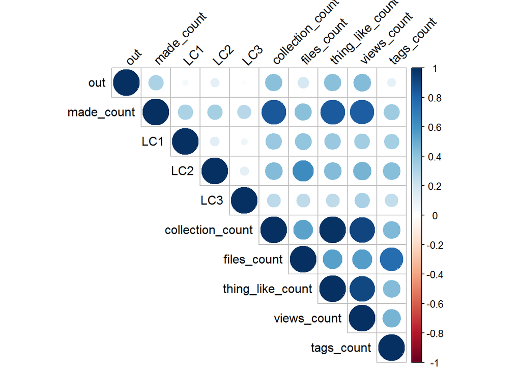

### Heterogeneous Correlation Matrix.

Correlation between qualitative and quantitative variables such as **appropriability strategy** and **license choice**.

```r
library(sjstats)
etaCor<-matrix(1,3,1)
rownames(etaCor)<-c("LC1","LC2","LC3")
colnames(etaCor)<-c("appropriability_strategy")

temp <- license.df %>%
        mutate(LC1= ifelse(LC1>0,1,0),
               LC2 =ifelse(LC2>0,1,0),
               LC3=ifelse(LC3>0,1,0)) %>%
        select(LC1,LC2,LC3, appropriability_strategy)


#ETA-squared
eta1 <- aov(LC1 ~ appropriability_strategy, temp)
eta2 <- aov(LC2 ~ appropriability_strategy, temp)
eta3 <- aov(LC2 ~ appropriability_strategy, temp)
etaCor[1,1]<- (eta_sq(eta1))
etaCor[2,1]<- (eta_sq(eta2))
etaCor[3,1]<- (eta_sq(eta3))
kable(etaCor)
```

|  | appropriability_strategy |
| --- | --- |
| LC1 | 0.02 |
| LC2 | 0.01 |
| LC3 | 0.01 |

Since the *appropriability_strategy* is a nominal qualitative variable, the best way to measure the correlation between interval variables such as *LC1,LC2,LC3* and *appropriability_strategy* is using **eta-squared**

## 3b. Use a multinomial logistic regression with license choice as the dependent variable and use appropriability strategy to predict the choice of license choice (this provides a validity check that private-collective appropriability strategy is more likely to choose “attribution” (LC2), free-riding is more likely to choose antibusiness licenses (LC3), and private appropriability strategy is more likely to choose LC1. This provides testing of our first set of research hypotheses

I did not used the **multinomial logistic regression** because license choice it is not a multinomial variable anymore. We aggregated the data and counted the number of times that license choice was found by *thing_author_id* and *key.event*. Instead of that, I ran a Multivariate multiple regression:

| Coefficients | LC1 | LC2 | LC3 |
| --- | --- | --- | --- |
| (Intercept) | 0.56 | 2.76 | 0.57 |
| appropriability_strategyfree-riding | -0.31 | -1.95 | -0.14 |
| appropriability_strategyprivate | -0.41 | -2.04 | -0.20 |
| collection_count | 0.00 | 0.00 | 0.00 |
| files_count | 0.02 | 0.07 | 0.01 |
| key.event2 | -0.01 | 0.38 | -0.41 |
| key.event3 | -0.02 | 0.36 | -0.41 |
| made_count | 0.01 | -0.01 | 0.02 |
| thing_like_count | 0.00 | 0.00 | 0.00 |

| Std. Error | LC1 | LC2 | LC3 |
| --- | --- | --- | --- |
| (Intercept) | 0.03 | 0.04 | 0.02 |
| appropriability_strategyfree-riding | 0.02 | 0.03 | 0.01 |
| appropriability_strategyprivate | 0.02 | 0.03 | 0.01 |
| collection_count | 0.00 | 0.00 | 0.00 |
| files_count | 0.00 | 0.00 | 0.00 |
| key.event2 | 0.03 | 0.04 | 0.01 |
| key.event3 | 0.03 | 0.04 | 0.01 |
| made_count | 0.00 | 0.00 | 0.00 |
| thing_like_count | 0.00 | 0.00 | 0.00 |

| Z-value | LC1 | LC2 | LC3 |
| --- | --- | --- | --- |
| (Intercept) | 18.28 | 67.1 | 34.7 |
| appropriability_strategyfree-riding | -12.58 | -59.2 | -11.0 |
| appropriability_strategyprivate | -16.54 | -62.1 | -15.3 |
| collection_count | 5.80 | 7.9 | 1.9 |
| files_count | 50.48 | 122.4 | 30.2 |
| key.event2 | -0.52 | 10.6 | -28.9 |
| key.event3 | -0.62 | 10.2 | -29.1 |
| made_count | 7.13 | -3.7 | 24.9 |
| thing_like_count | -0.04 | -2.7 | -2.9 |

| P-value | LC1 | LC2 | LC3 |
| --- | --- | --- | --- |
| (Intercept) | 0.00 | 0.00 | 0.00 |
| appropriability_strategyfree-riding | 0.00 | 0.00 | 0.00 |
| appropriability_strategyprivate | 0.00 | 0.00 | 0.00 |
| collection_count | 0.00 | 0.00 | 0.06 |
| files_count | 0.00 | 0.00 | 0.00 |
| key.event2 | 0.61 | 0.00 | 0.00 |
| key.event3 | 0.54 | 0.00 | 0.00 |
| made_count | 0.00 | 0.00 | 0.00 |
| thing_like_count | 0.97 | 0.01 | 0.00 |

The **LC1** model presents Multiple R-squared: 0.248 and Adjusted R-squared: 0.248. The **LC2** model presents Multiple R-squared: 0.541, Adjusted R-squared: 0.54 and finally, the **LC3** model presents Multiple R-squared: 0.192, Adjusted R-squared: 0.192.

The Manova results are:

```
##                             Df Pillai approx F num Df den Df
## appropriability_strategy     2  0.335     3124      6  93184
## key.event                    2  0.034      267      6  93184
## collection_count             1  0.373     9253      3  46591
## files_count                  1  0.347     8257      3  46591
## thing_like_count             1  0.000        5      3  46591
## made_count                   1  0.015      237      3  46591
## Residuals                46593
##                                       Pr(>F)
## appropriability_strategy <0.0000000000000002 ***
## key.event                <0.0000000000000002 ***
## collection_count         <0.0000000000000002 ***
## files_count              <0.0000000000000002 ***
## thing_like_count                       0.003 **
## made_count               <0.0000000000000002 ***
## Residuals
## ---
## Signif. codes:  0 '***' 0.001 '**' 0.01 '*' 0.05 '.' 0.1 ' ' 1
```

## 2c. Remember to run the interaction effect between AS and period. Can you carry out some sort of 2-step model, model one includes all the control, and the main predictors, and model two adds the interaction effect. And then compare the significant changes between model one and model using R-squared change.

Here the same Multivariate Regression Model with the AS and Key.period interaction

| Coefficients | LC1 | LC2 | LC3 |
| --- | --- | --- | --- |
| (Intercept) | 0.38 | 2.62 | 1.27 |
| appropriability_strategyfree-riding | -0.43 | -2.03 | -1.16 |
| appropriability_strategyfree-riding:key.event2 | 0.14 | -0.23 | 1.15 |
| appropriability_strategyfree-riding:key.event3 | 0.05 | 0.32 | 1.15 |
| appropriability_strategyprivate | -0.15 | -1.84 | -1.06 |
| appropriability_strategyprivate:key.event2 | -0.29 | -0.47 | 1.04 |
| appropriability_strategyprivate:key.event3 | -0.33 | -0.03 | 1.02 |
| collection_count | 0.00 | 0.00 | 0.00 |
| files_count | 0.02 | 0.07 | 0.01 |
| key.event2 | 0.17 | 0.77 | -1.24 |
| key.event3 | 0.23 | 0.31 | -1.24 |
| made_count | 0.01 | -0.01 | 0.01 |
| thing_like_count | 0.00 | 0.00 | 0.00 |

| Std. Error | LC1 | LC2 | LC3 |
| --- | --- | --- | --- |
| (Intercept) | 0.05 | 0.07 | 0.03 |
| appropriability_strategyfree-riding | 0.10 | 0.14 | 0.05 |
| appropriability_strategyfree-riding:key.event2 | 0.11 | 0.14 | 0.06 |
| appropriability_strategyfree-riding:key.event3 | 0.11 | 0.14 | 0.06 |
| appropriability_strategyprivate | 0.06 | 0.08 | 0.03 |
| appropriability_strategyprivate:key.event2 | 0.07 | 0.09 | 0.04 |
| appropriability_strategyprivate:key.event3 | 0.07 | 0.09 | 0.04 |
| collection_count | 0.00 | 0.00 | 0.00 |
| files_count | 0.00 | 0.00 | 0.00 |
| key.event2 | 0.06 | 0.08 | 0.03 |
| key.event3 | 0.06 | 0.08 | 0.03 |
| made_count | 0.00 | 0.00 | 0.00 |
| thing_like_count | 0.00 | 0.00 | 0.00 |

| Z-value | LC1 | LC2 | LC3 |
| --- | --- | --- | --- |
| (Intercept) | 7.34 | 37.75 | 46.6 |
| appropriability_strategyfree-riding | -4.19 | -14.84 | -21.6 |
| appropriability_strategyfree-riding:key.event2 | 1.31 | -1.58 | 20.3 |
| appropriability_strategyfree-riding:key.event3 | 0.46 | 2.21 | 20.3 |
| appropriability_strategyprivate | -2.66 | -23.91 | -35.0 |
| appropriability_strategyprivate:key.event2 | -4.26 | -5.22 | 29.2 |
| appropriability_strategyprivate:key.event3 | -4.82 | -0.28 | 28.6 |
| collection_count | 6.06 | 6.70 | 1.6 |
| files_count | 50.55 | 122.63 | 29.6 |
| key.event2 | 2.85 | 9.69 | -39.8 |
| key.event3 | 3.79 | 3.87 | -39.1 |
| made_count | 7.42 | -3.09 | 22.1 |
| thing_like_count | -0.34 | -1.69 | -2.5 |

| P-value | LC1 | LC2 | LC3 |
| --- | --- | --- | --- |
| (Intercept) | 0.00 | 0.00 | 0.00 |
| appropriability_strategyfree-riding | 0.00 | 0.00 | 0.00 |
| appropriability_strategyfree-riding:key.event2 | 0.19 | 0.11 | 0.00 |
| appropriability_strategyfree-riding:key.event3 | 0.64 | 0.03 | 0.00 |
| appropriability_strategyprivate | 0.01 | 0.00 | 0.00 |
| appropriability_strategyprivate:key.event2 | 0.00 | 0.00 | 0.00 |
| appropriability_strategyprivate:key.event3 | 0.00 | 0.78 | 0.00 |
| collection_count | 0.00 | 0.00 | 0.11 |
| files_count | 0.00 | 0.00 | 0.00 |
| key.event2 | 0.00 | 0.00 | 0.00 |
| key.event3 | 0.00 | 0.00 | 0.00 |
| made_count | 0.00 | 0.00 | 0.00 |
| thing_like_count | 0.73 | 0.09 | 0.01 |

The Manova results are:

```
##                                       Df Pillai approx F num Df den Df
## appropriability_strategy               2  0.336     3131      6  93176
## key.event                              2  0.034      272      6  93176
## collection_count                       1  0.374     9281      3  46587
## files_count                            1  0.348     8275      3  46587
## thing_like_count                       1  0.000        5      3  46587
## made_count                             1  0.015      242      3  46587
## appropriability_strategy:key.event     4  0.024       94     12 139767
## Residuals                          46589
##                                                 Pr(>F)
## appropriability_strategy           <0.0000000000000002 ***
## key.event                          <0.0000000000000002 ***
## collection_count                   <0.0000000000000002 ***
## files_count                        <0.0000000000000002 ***
## thing_like_count                                0.0028 **
## made_count                         <0.0000000000000002 ***
## appropriability_strategy:key.event <0.0000000000000002 ***
## Residuals
## ---
## Signif. codes:  0 '***' 0.001 '**' 0.01 '*' 0.05 '.' 0.1 ' ' 1
```

2d. because one of the research hypotheses is about private-collective is more likely to sustain contribution. it’ll be useful to plot the interaction effects (see the attached for an illustration of the interaction between LC and period)

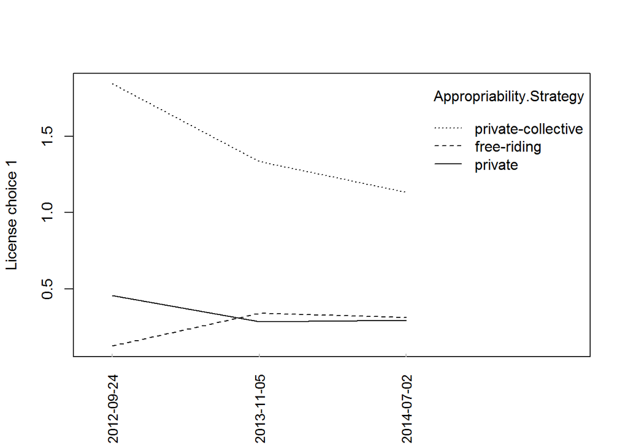

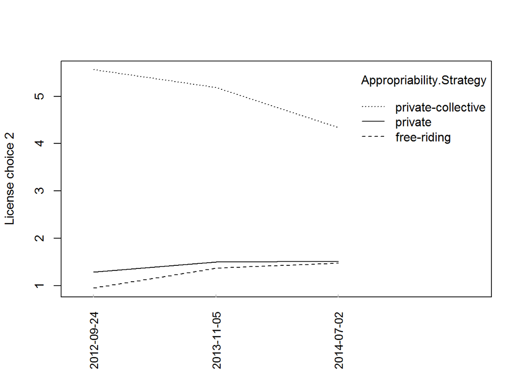

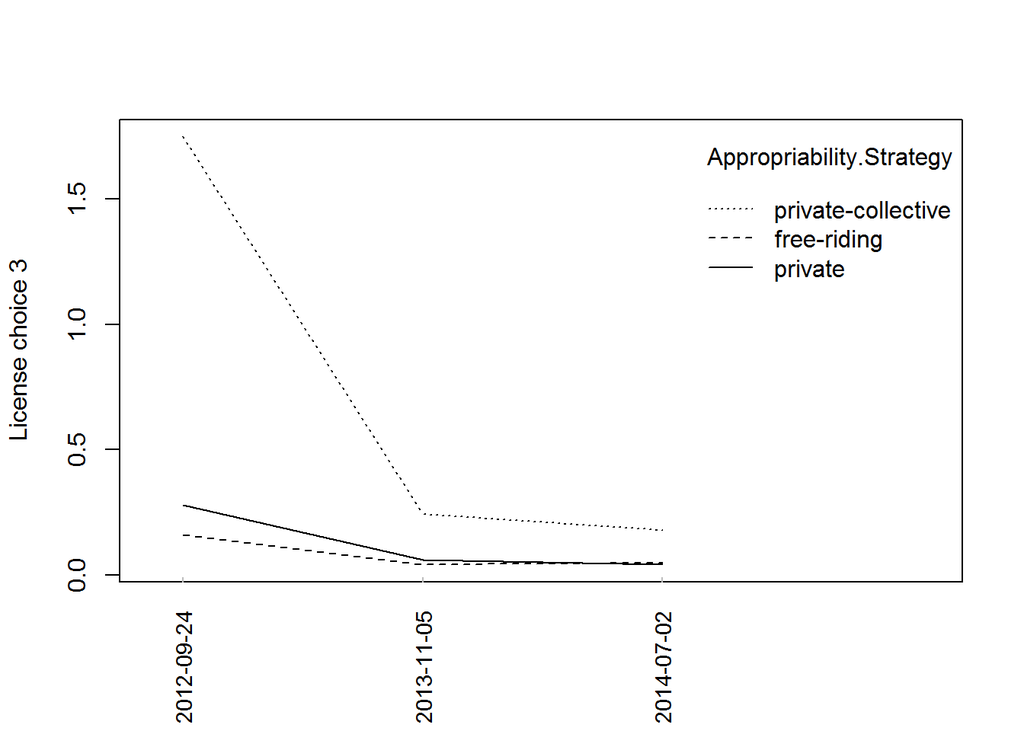

# 4. Use the zero inflated neg binomial (zinb) for modelling the effects on “out”.

## 4a. Model 1: the usual control variables (files count, likes, period and perhaps collection)

```r
library(pscl)
m1 <- zeroinfl(out ~ files_count+thing_like_count+collection_count+key.event | files_count+thing_like_count+collection_count,
               data = license.df, dist = "negbin", EM = TRUE)
summary(m1)
```

```
##
## Call:
## zeroinfl(formula = out ~ files_count + thing_like_count + collection_count +
##     key.event | files_count + thing_like_count + collection_count,
##     data = license.df, dist = "negbin", EM = TRUE)
##
## Pearson residuals:
##      Min       1Q   Median       3Q      Max
##  -0.4780  -0.1433  -0.0692  -0.0643 158.3929
##
## Count model coefficients (negbin with log link):
##                   Estimate Std. Error z value             Pr(>|z|)
## (Intercept)      -0.226475   0.048250   -4.69        0.00000268187 ***
## files_count       0.004659   0.001090    4.27        0.00001924789 ***
## thing_like_count -0.002002   0.000431   -4.64        0.00000344735 ***
## collection_count  0.005136   0.000385   13.34 < 0.0000000000000002 ***
## key.event2        0.993629   0.051800   19.18 < 0.0000000000000002 ***
## key.event3        0.351567   0.056937    6.17        0.00000000066 ***
## Log(theta)       -1.476153   0.020821  -70.90 < 0.0000000000000002 ***
##
## Zero-inflation model coefficients (binomial with logit link):
##                  Estimate Std. Error z value            Pr(>|z|)
## (Intercept)       3.62991    0.06090   59.61 <0.0000000000000002 ***
## files_count       0.00265    0.00223    1.19                0.23
## thing_like_count -0.00403    0.00990   -0.41                0.68
## collection_count -0.14980    0.00965  -15.52 <0.0000000000000002 ***
## ---
## Signif. codes:  0 '***' 0.001 '**' 0.01 '*' 0.05 '.' 0.1 ' ' 1
##
## Theta = 0.229
## Number of iterations in BFGS optimization: 1
## Log-likelihood: -2.38e+04 on 11 Df
```

## 4b. Model 2: the main effects of AS and LC: Private-collective

```r
#Define the reference (Private-collective)
license.df <- within(license.df, appropriability_strategy <- relevel(appropriability_strategy, ref = "private-collective"))
m2 <- zeroinfl(out ~ files_count+thing_like_count+collection_count+key.event+appropriability_strategy+LC1+LC2+LC3
                 | files_count+thing_like_count+collection_count+appropriability_strategy+LC1+LC2+LC3,
               data = license.df, dist = "negbin", EM = TRUE)
save.image("Chunk18.RData")
summary(m2)
```

```
##
## Call:
## zeroinfl(formula = out ~ files_count + thing_like_count + collection_count +
##     key.event + appropriability_strategy + LC1 + LC2 + LC3 | files_count +
##     thing_like_count + collection_count + appropriability_strategy +
##     LC1 + LC2 + LC3, data = license.df, dist = "negbin", EM = TRUE)
##
## Pearson residuals:
##      Min       1Q   Median       3Q      Max
##  -0.4925  -0.1571  -0.0759  -0.0540 243.8804
##
## Count model coefficients (negbin with log link):
##                                      Estimate Std. Error z value
## (Intercept)                          0.173516   0.065543    2.65
## files_count                         -0.002080   0.000574   -3.62
## thing_like_count                    -0.001000   0.000407   -2.46
## collection_count                     0.003839   0.000358   10.71
## key.event2                           0.909291   0.052035   17.47
## key.event3                           0.212982   0.057344    3.71
## appropriability_strategyfree-riding  0.077141   0.081486    0.95
## appropriability_strategyprivate     -0.722803   0.051323  -14.08
## LC1                                  0.007323   0.008292    0.88
## LC2                                  0.038883   0.006951    5.59
## LC3                                  0.055356   0.016997    3.26
## Log(theta)                          -1.416691   0.021133  -67.04
##                                                 Pr(>|z|)
## (Intercept)                                      0.00811 **
## files_count                                      0.00029 ***
## thing_like_count                                 0.01401 *
## collection_count                    < 0.0000000000000002 ***
## key.event2                          < 0.0000000000000002 ***
## key.event3                                       0.00020 ***
## appropriability_strategyfree-riding              0.34380
## appropriability_strategyprivate     < 0.0000000000000002 ***
## LC1                                              0.37715
## LC2                                          0.000000022 ***
## LC3                                              0.00113 **
## Log(theta)                          < 0.0000000000000002 ***
##
## Zero-inflation model coefficients (binomial with logit link):
```

[output cut: 11 more lines]

```
## (Intercept)                         < 0.0000000000000002 ***
## files_count                                      0.16624
## thing_like_count                                 0.50004
## collection_count                    < 0.0000000000000002 ***
## appropriability_strategyfree-riding < 0.0000000000000002 ***
## appropriability_strategyprivate               0.00000084 ***
## LC1                                              0.00026 ***
## LC2                                           0.00004024 ***
## LC3                                              0.06461 .
## ---
## Signif. codes:  0 '***' 0.001 '**' 0.01 '*' 0.05 '.' 0.1 ' ' 1
##
## Theta = 0.243
## Number of iterations in BFGS optimization: 24
## Log-likelihood: -2.35e+04 on 21 Df
```

## 4c. Model 3: testing the following two sets of interaction effects (H4, H5)

Appropriability strategy x Period (or key events):

```r
m3 <- zeroinfl(out ~ files_count+thing_like_count+collection_count+key.event+appropriability_strategy+LC1+LC2+LC3+(appropriability_strategy*key.event)
                 | files_count+thing_like_count+collection_count+appropriability_strategy+LC1+LC2+LC3+(appropriability_strategy*key.event),
               data = license.df, dist = "negbin", EM = TRUE)
summary(m3)
save.image("Chunk19.RData")
```

```
##
## Call:
## zeroinfl(formula = out ~ files_count + thing_like_count + collection_count +
##     key.event + appropriability_strategy + LC1 + LC2 + LC3 + (appropriability_strategy *
##     key.event) | files_count + thing_like_count + collection_count +
##     appropriability_strategy + LC1 + LC2 + LC3 + (appropriability_strategy *
##     key.event), data = license.df, dist = "negbin", EM = TRUE)
##
## Pearson residuals:
##      Min       1Q   Median       3Q      Max
##  -0.5101  -0.1561  -0.0745  -0.0440 224.9917
##
## Count model coefficients (negbin with log link):
##                                                 Estimate Std. Error
## (Intercept)                                     0.055570   0.075772
## files_count                                    -0.001796   0.000527
## thing_like_count                               -0.001169   0.000404
## collection_count                                0.003846   0.000356
## key.event2                                      1.184901   0.080190
## key.event3                                      0.492989   0.091354
## appropriability_strategyfree-riding            -0.018439   0.164165
## appropriability_strategyprivate                -0.572184   0.085521
## LC1                                             0.005241   0.008047
## LC2                                             0.033054   0.006746
## LC3                                             0.055948   0.016249
## key.event2:appropriability_strategyfree-riding -0.459829   0.195198
## key.event3:appropriability_strategyfree-riding  0.666429   0.217597
## key.event2:appropriability_strategyprivate     -0.169744   0.107877
## key.event3:appropriability_strategyprivate     -0.201577   0.119898
## Log(theta)                                     -1.346423   0.021705
##                                                z value
## (Intercept)                                       0.73
## files_count                                      -3.41
## thing_like_count                                 -2.90
## collection_count                                 10.82
## key.event2                                       14.78
## key.event3                                        5.40
## appropriability_strategyfree-riding              -0.11
## appropriability_strategyprivate                  -6.69
## LC1                                               0.65
```

[output cut: 49 more lines]

```
## LC1                                                         0.00031 ***
## LC2                                                         0.00723 **
## LC3                                                         0.10540
## key.event2                                                  0.00169 **
## key.event3                                                  0.00026 ***
## appropriability_strategyfree-riding:key.event2              0.98662
## appropriability_strategyprivate:key.event2                  0.08190 .
## appropriability_strategyfree-riding:key.event3              0.54772
## appropriability_strategyprivate:key.event3                  0.04769 *
## ---
## Signif. codes:  0 '***' 0.001 '**' 0.01 '*' 0.05 '.' 0.1 ' ' 1
##
## Theta = 0.26
## Number of iterations in BFGS optimization: 36
## Log-likelihood: -2.34e+04 on 31 Df
```

Note that by definition **Appropriability strategy = Design Strategy** so it does not make sense to test this interaction.

# Repeat the above steps with the outcome measure: “made”.

## 4a. Model 1: the usual control variables (files count, likes, period and perhaps collection)

```r
library(pscl)
m1 <- zeroinfl(made_count ~ files_count+thing_like_count+collection_count+key.event | files_count+thing_like_count+collection_count,
               data = license.df, dist = "negbin", EM = TRUE)
summary(m1)
```

```
##
## Call:
## zeroinfl(formula = made_count ~ files_count + thing_like_count +
##     collection_count + key.event | files_count + thing_like_count +
##     collection_count, data = license.df, dist = "negbin", EM = TRUE)
##
## Pearson residuals:
##    Min     1Q Median     3Q    Max
## -0.859 -0.189 -0.111 -0.104 65.935
##
## Count model coefficients (negbin with log link):
##                   Estimate Std. Error z value            Pr(>|z|)
## (Intercept)       0.693751   0.027881   24.88 <0.0000000000000002 ***
## files_count       0.000120   0.000459    0.26              0.7936
## thing_like_count  0.000852   0.000271    3.14              0.0017 **
## collection_count  0.002919   0.000227   12.88 <0.0000000000000002 ***
## key.event2       -0.485866   0.029036  -16.73 <0.0000000000000002 ***
## key.event3       -0.822668   0.031754  -25.91 <0.0000000000000002 ***
## Log(theta)       -0.303336   0.020800  -14.58 <0.0000000000000002 ***
##
## Zero-inflation model coefficients (binomial with logit link):
##                  Estimate Std. Error z value             Pr(>|z|)
## (Intercept)       3.24532    0.04867   66.68 < 0.0000000000000002 ***
## files_count      -0.00497    0.00474   -1.05                 0.29
## thing_like_count -0.05752    0.00956   -6.02         0.0000000018 ***
## collection_count -0.15783    0.00918  -17.19 < 0.0000000000000002 ***
## ---
## Signif. codes:  0 '***' 0.001 '**' 0.01 '*' 0.05 '.' 0.1 ' ' 1
##
## Theta = 0.738
## Number of iterations in BFGS optimization: 1
## Log-likelihood: -3.17e+04 on 11 Df
```

## 4b. Model 2: the main effects of AS and LC: Private-collective

```r
m2 <- zeroinfl(made_count ~ files_count+thing_like_count+collection_count+key.event+appropriability_strategy+LC1+LC2+LC3
                 | files_count+thing_like_count+collection_count+appropriability_strategy+LC1+LC2+LC3,
               data = license.df, dist = "negbin", EM = TRUE)
summary(m2)
```

```
##
## Call:
## zeroinfl(formula = made_count ~ files_count + thing_like_count +
##     collection_count + key.event + appropriability_strategy + LC1 +
##     LC2 + LC3 | files_count + thing_like_count + collection_count +
##     appropriability_strategy + LC1 + LC2 + LC3, data = license.df,
##     dist = "negbin", EM = TRUE)
##
## Pearson residuals:
##     Min      1Q  Median      3Q     Max
## -0.8845 -0.2078 -0.1032 -0.0894 53.1197
##
## Count model coefficients (negbin with log link):
##                                      Estimate Std. Error z value
## (Intercept)                          0.889379   0.036252   24.53
## files_count                         -0.003517   0.000433   -8.12
## thing_like_count                     0.000903   0.000262    3.45
## collection_count                     0.002463   0.000215   11.43
## key.event2                          -0.520766   0.029372  -17.73
## key.event3                          -0.864928   0.032050  -26.99
## appropriability_strategyfree-riding -0.341286   0.047819   -7.14
## appropriability_strategyprivate     -0.275991   0.028252   -9.77
## LC1                                  0.027608   0.005183    5.33
## LC2                                  0.028485   0.003805    7.49
## LC3                                  0.025550   0.008363    3.06
## Log(theta)                          -0.245444   0.021120  -11.62
##                                                 Pr(>|z|)
## (Intercept)                         < 0.0000000000000002 ***
## files_count                          0.00000000000000045 ***
## thing_like_count                                 0.00056 ***
## collection_count                    < 0.0000000000000002 ***
## key.event2                          < 0.0000000000000002 ***
## key.event3                          < 0.0000000000000002 ***
## appropriability_strategyfree-riding  0.00000000000095377 ***
## appropriability_strategyprivate     < 0.0000000000000002 ***
## LC1                                  0.00000009989433916 ***
## LC2                                  0.00000000000007064 ***
## LC3                                              0.00225 **
## Log(theta)                          < 0.0000000000000002 ***
##
```

[output cut: 12 more lines]

```
## (Intercept)                         < 0.0000000000000002 ***
## files_count                                        0.220
## thing_like_count                      0.0000079871733200 ***
## collection_count                    < 0.0000000000000002 ***
## appropriability_strategyfree-riding   0.0000000000000066 ***
## appropriability_strategyprivate                    0.519
## LC1                                                0.074 .
## LC2                                   0.0000280046303917 ***
## LC3                                                0.586
## ---
## Signif. codes:  0 '***' 0.001 '**' 0.01 '*' 0.05 '.' 0.1 ' ' 1
##
## Theta = 0.782
## Number of iterations in BFGS optimization: 1
## Log-likelihood: -3.15e+04 on 21 Df
```

## 4c. Model 3: testing the following two sets of interaction effects (H4, H5)

Appropriability strategy x Period (or key events):

```r
m3 <- zeroinfl(made_count ~ files_count+thing_like_count+collection_count+key.event+appropriability_strategy+LC1+LC2+LC3+(appropriability_strategy*key.event)
                 | files_count+thing_like_count+collection_count+appropriability_strategy+LC1+LC2+LC3+(appropriability_strategy*key.event),
               data = license.df, dist = "negbin", EM = TRUE)
summary(m3)
```

```
##
## Call:
## zeroinfl(formula = made_count ~ files_count + thing_like_count +
##     collection_count + key.event + appropriability_strategy + LC1 +
##     LC2 + LC3 + (appropriability_strategy * key.event) | files_count +
##     thing_like_count + collection_count + appropriability_strategy +
##     LC1 + LC2 + LC3 + (appropriability_strategy * key.event), data = license.df,
##     dist = "negbin", EM = TRUE)
##
## Pearson residuals:
##     Min      1Q  Median      3Q     Max
## -0.8874 -0.2106 -0.1008 -0.0869 51.7935
##
## Count model coefficients (negbin with log link):
##                                                 Estimate Std. Error
## (Intercept)                                     0.906793   0.044959
## files_count                                    -0.003528   0.000433
## thing_like_count                                0.000879   0.000262
## collection_count                                0.002472   0.000216
## key.event2                                     -0.558565   0.047799
## key.event3                                     -0.846955   0.053104
## appropriability_strategyfree-riding            -0.274907   0.098987
## appropriability_strategyprivate                -0.303440   0.049241
## LC1                                             0.027481   0.005173
## LC2                                             0.028504   0.003803
## LC3                                             0.025409   0.008378
## key.event2:appropriability_strategyfree-riding  0.008101   0.118119
## key.event3:appropriability_strategyfree-riding -0.261579   0.129580
## key.event2:appropriability_strategyprivate      0.077868   0.062407
## key.event3:appropriability_strategyprivate     -0.013146   0.067554
## Log(theta)                                     -0.238927   0.021235
##                                                z value
## (Intercept)                                      20.17
## files_count                                      -8.16
## thing_like_count                                  3.35
## collection_count                                 11.45
## key.event2                                      -11.69
## key.event3                                      -15.95
## appropriability_strategyfree-riding              -2.78
## appropriability_strategyprivate                  -6.16
```

[output cut: 50 more lines]

```
## LC1                                                         0.14515
## LC2                                                0.00001323615769 ***
## LC3                                                         0.46134
## key.event2                                                  0.93436
## key.event3                                                  0.60455
## appropriability_strategyfree-riding:key.event2              0.00094 ***
## appropriability_strategyprivate:key.event2                  0.75110
## appropriability_strategyfree-riding:key.event3              0.00476 **
## appropriability_strategyprivate:key.event3                  0.19234
## ---
## Signif. codes:  0 '***' 0.001 '**' 0.01 '*' 0.05 '.' 0.1 ' ' 1
##
## Theta = 0.787
## Number of iterations in BFGS optimization: 1
## Log-likelihood: -3.14e+04 on 31 Df
```